# Clase 7

# Tarea 7.

# Validación

Librerias

```r
library(caTools)
library(rpart)
library(tidyverse)
library(randomForest)
library(neuralnet)
library(class)
library(caret)
library(e1071)
library(ROCR)
```

1. Desarolle el Análisis del Problema.
2. Cargue el archivo nombre.csv en una variable.
3. Desarolle el Entendimiento de los Datos.
4. Utilizando barplot cree un gráfico de los atributos del dataset, observe las correlaciones entre atributos.
5. Realice al menos 5 modelos de los observados en clase.
6. Evaluación de los modelos.
7. Desarolle al menos 5 conclusiones sobre las clasificaciones de los modelos.

## Análisis del Problema

**Basado en la tarea 6 teníamos el siguiente enunciado:**

El Consejo de Seguridad Vial de Costa Rica (COSEVI) posee en su portal de datos abiertos información sobre: accidentes de tránsito, personas accidentadas, fallecidos en sitio, conductores y licencias, infracciones y pruebas teóricas y prácticas.

En el caso de los accidentes de tránsito con víctimas (donde al menos una persona resultó herida o fallecida) los datos se obtienen mediante el parte oficial de tránsito que realiza la Dirección General de Policía de Tránsito al presentarse un accidente, los cuales ingresan a la base de datos de dos formas (hand held y papel). Debido a que parte de la labor principal de la Institución es salvar vidas, y por los recursos limitados que existen, se trabaja solo con accidentes con heridos y/o fallecidos; y no se trabaja con accidentes que presentan solo daños materiales. Además, posteriormente inicia el proceso de limpieza, corrección de inconsistencias, validación de algunas variables, georeferenciación de los accidentes, entre otros.

La fuente de los datos entre 2013-2017 se encuentra en: http://datosabiertos.csv.go.cr/dashboards/19683/accidentes/.

Accidente con víctima se refiere cuando en el accidente de tránsito al menos uno de los participantes resulto: herido leve, grave o fallecido. Algunos tipos de lesión (herido grave, herido leve e ileso) son una valoración subjetiva realizada por el oficial de tránsito al llegar al sitio, sin criterio médico. Los fallecidos son los que ocurren en el lugar de los hechos o durante el traslado, no involucra los que se presentan en el hospital.

Otro dataset importante es el de las personas accidentadas entre 2013-2017 disponible en: http://datosabiertos.csv.go.cr/dashboards/19745/personas-accidentadas/. En donde se presentan las características de personas involucradas en accidentes con víctimas, los datos se obtienen del parte oficial de tránsito.

Se pretende utilizar este último dataset para determinar un modelo de clasificación de las víctimas de un accidente según la información dentro de las variables del dataset:

- **Rol**: que rol presentaba la víctima durante el accidente entre conductor, motociclista, ciclista, peatón, pasajero moto, pasajero carro, pasajero bicicleta, pasajero bus o microbús, dueño de propiedad, otro (categórica).
- **Tipo de lesión**: categoría de lesión entre ileso, herido leve, herido grave, muerte (categórica).
- **Edad**: edad de la víctima del accidente (numérica discreta).
- **Edad Quinquenal**: rango de edades cada 5 años (categórica ordinal).
- **Sexo**: sexo de la víctima (categórica).
- **Año**: año en que ocurrió el accidente (numérica discreta).
- **Mes**: mes en que ocurrió el accidente (categórica).
- **Día**: día en que ocurrió el accidente (categórica).
- **Provincia**: provincia del país en que ocurrió el accidente (categórica).
- **Cantón**: cantón de la provincia en que ocurrió el accidente (categórica).
- **Distrito**: distrito del cantón en que ocurrió el accidente (categórica).

**La idea con estos datos es determinar cuáles pueden emplearse para clasificar las víctimas de un accidente según el tipo de lesión y poder lograr responder efectivamente a este tipo de accidentes de una forma mejor para evitar o reducir víctimas mortales.**

**Adicional, como elemento fundamental de este entregable, es la implementación de una fase de validación más exaustiva de los modelos, hiperparametrización de los modelos, creación de matrices de confusión, y gráficas de la curva ROC de cada uno de los modelos implementados previamente.**

## Carga de Datos

A continuación se carga el dataset obtenido de las personas accidentadas entre 2013-2017.

```r
data <- read.csv("temp_5571830814335439232.csv")
head(data)
```

```
##   A_Persona           Rol Tipo.de.lesión        Edad Edad.quinquenal
## 1         1 Pasajero moto    Herido leve          15      De 15 a 19
## 2         1  Motociclista         Muerte          47      De 45 a 49
## 3         1 Pasajero moto    Herido leve Desconocido     Desconocida
## 4         1  Motociclista          Ileso          20      De 20 a 24
## 5         1 Pasajero moto    Herido leve Desconocido     Desconocida
## 6         1 Pasajero moto    Herido leve          28      De 25 a 29
##     Sexo  Año     Mes       Día  Provincia    Cantón    Distrito
## 1  Mujer 2015   Enero   Domingo Puntarenas Coto Brus    Sabalito
## 2 Hombre 2015   Enero   Domingo Puntarenas Coto Brus    Sabalito
## 3 Hombre 2013   Marzo   Domingo   San José  San José    Hospital
## 4 Hombre 2013   Marzo   Domingo   San José  San José    Hospital
## 5 Hombre 2013   Marzo   Domingo   San José  San José    Hospital
## 6  Mujer 2013 Febrero Miércoles   San José  Puriscal San Antonio
##         Día.1      Mes.1 Edad.quinquenal.1
## 1   1.Domingo   A. Enero           15 A 19
## 2   1.Domingo   A. Enero           45 A 49
## 3   1.Domingo   C. Marzo       Desconocida
## 4   1.Domingo   C. Marzo           20 A 24
## 5   1.Domingo   C. Marzo       Desconocida
## 6 4.Miércoles B. Febrero           25 A 29
```

Cómo se observa los datos fueron cargados correctamente. En la siguiente sección vamos a visualizar algunas estadísticas, limpiar/transformar valores y observar relaciones entre datos.

## Entendimiento de los Datos

```r
glimpse(data)
```

```
## Observations: 158,399
## Variables: 15
## $ A_Persona         <int> 1, 1, 1, 1, 1, 1, 1, 1, 1, 1, 1, 1, 1, 1, 1, 1…
## $ Rol               <fct> Pasajero moto, Motociclista, Pasajero moto, Mo…
## $ Tipo.de.lesión    <fct> Herido leve, Muerte, Herido leve, Ileso, Herid…
## $ Edad              <fct> 15, 47, Desconocido, 20, Desconocido, 28, 30, …
## $ Edad.quinquenal   <fct> De 15 a 19, De 45 a 49, Desconocida, De 20 a 2…
## $ Sexo              <fct> Mujer, Hombre, Hombre, Hombre, Hombre, Mujer, …
## $ Año               <int> 2015, 2015, 2013, 2013, 2013, 2013, 2013, 2013…
## $ Mes               <fct> Enero, Enero, Marzo, Marzo, Marzo, Febrero, Fe…
## $ Día               <fct> Domingo, Domingo, Domingo, Domingo, Domingo, M…
## $ Provincia         <fct> Puntarenas, Puntarenas, San José, San José, Sa…
## $ Cantón            <fct> Coto Brus, Coto Brus, San José, San José, San …
## $ Distrito          <fct> Sabalito, Sabalito, Hospital, Hospital, Hospit…
## $ Día.1             <fct> 1.Domingo, 1.Domingo, 1.Domingo, 1.Domingo, 1.…
## $ Mes.1             <fct> A. Enero, A. Enero, C. Marzo, C. Marzo, C. Mar…
## $ Edad.quinquenal.1 <fct> 15 A 19, 45 A 49, Desconocida, 20 A 24, Descon…
```

```r
summary(data$A_Persona)
```

```
##    Min. 1st Qu.  Median    Mean 3rd Qu.    Max.
##       1       1       1       1       1       1
```

```r
levels(data$Rol)
```

```
##  [1] "Ciclista"                "Conductor"
##  [3] "Dueño de propiedad"      "Motociclista"
##  [5] "Otro"                    "Pasajero bicicleta"
##  [7] "Pasajero bus o microbús" "Pasajero carro"
##  [9] "Pasajero moto"           "Peatón"
```

```r
levels(data$Tipo.de.lesión)
```

```
## [1] "Herido grave" "Herido leve"  "Ileso"        "Muerte"
```

```r
levels(data$Edad)
```

```
##   [1] "0"           "1"           "10"          "11"          "12"
##   [6] "13"          "14"          "15"          "16"          "17"
##  [11] "18"          "19"          "2"           "20"          "21"
##  [16] "22"          "23"          "24"          "25"          "26"
##  [21] "27"          "28"          "29"          "3"           "30"
##  [26] "31"          "32"          "33"          "34"          "35"
##  [31] "36"          "37"          "38"          "39"          "4"
##  [36] "40"          "41"          "42"          "43"          "44"
##  [41] "45"          "46"          "47"          "48"          "49"
##  [46] "5"           "50"          "51"          "52"          "53"
##  [51] "54"          "55"          "56"          "57"          "58"
##  [56] "59"          "6"           "60"          "61"          "62"
##  [61] "63"          "64"          "65"          "66"          "67"
##  [66] "68"          "69"          "7"           "70"          "71"
##  [71] "72"          "73"          "74"          "75"          "76"
##  [76] "77"          "78"          "79"          "8"           "80"
##  [81] "81"          "82"          "83"          "84"          "85"
##  [86] "86"          "87"          "88"          "89"          "9"
##  [91] "90"          "91"          "92"          "93"          "94"
##  [96] "95"          "96"          "97"          "98"          "Desconocido"
```

```r
levels(data$Edad.quinquenal)
```

```
##  [1] "De 0 a 4"    "De 10 a 14"  "De 15 a 19"  "De 20 a 24"  "De 25 a 29"
##  [6] "De 30 a 34"  "De 35 a 39"  "De 40 a 44"  "De 45 a 49"  "De 5 a 9"
## [11] "De 50 a 54"  "De 55 a 59"  "De 60 a 64"  "De 65 a 69"  "De 70 a 74"
## [16] "Desconocida" "Mayor a 75"
```

Como se observa en la estructura inicial del dataset contamos con algunas variables duplicadas **(Día.1, Mes.1, Edad.quinquenal.1)**. A su vez la variable **A_Persona** parece no poseer ningún valor distinto a 1 (lo cual no es muy útil). La variable **Edad** es de tipo factor cuando debería ser numérica. Finalmente observamos, que las variables **Sexo**, **Edad** y **Edad.quinquenal** poseen valores “Desconocido” que deben ser removidos antes de implementar el modelo (representan 8216 registros del total de 158399, lo cual es alrededor del 5% de los registros).

Vamos a realizar estos cambios al dataset para poder continuar con el análisis exploratorio de los datos.

```r
data2 <- data %>%
  select(-A_Persona, -Día.1, -Mes.1, -Edad.quinquenal.1) %>%
  filter(Edad != "Desconocido") %>%
  mutate(Edad = as.integer(as.character(Edad)))
```

Otra modificación importante es ordenar las categorías de **Edad.quinquenal**.

```r
# Quitamos el level "Desconocida" que ya no posee datos.
# Ordenamos los levels según los rangos de edad.
data3 <- data2 %>%
  mutate(Edad.quinquenal = droplevels(Edad.quinquenal)) %>%
  mutate(Edad.quinquenal = ordered(Edad.quinquenal, c("De 0 a 4",  "De 5 a 9",   "De 10 a 14",  "De 15 a 19",  "De 20 a 24",  "De 25 a 29", "De 30 a 34",  "De 35 a 39",  "De 40 a 44",  "De 45 a 49", "De 50 a 54",  "De 55 a 59",  "De 60 a 64", "De 65 a 69",  "De 70 a 74", "Mayor a 75")))

# Validamos que los levels fueron ordenados y el valor "Desconocida" fue removido.
levels(data3$Edad.quinquenal)
```

```
##  [1] "De 0 a 4"   "De 5 a 9"   "De 10 a 14" "De 15 a 19" "De 20 a 24"
##  [6] "De 25 a 29" "De 30 a 34" "De 35 a 39" "De 40 a 44" "De 45 a 49"
## [11] "De 50 a 54" "De 55 a 59" "De 60 a 64" "De 65 a 69" "De 70 a 74"
## [16] "Mayor a 75"
```

Otro cambio importante basado en la forma en que se desea determinar el modelo es la forma en que se categorizan las personas accidentadas. Se requiere agrupar aquellas que requieren atención (herido leve, herido grave, muerto) y las que no (ileso).

```r
data4 <- data3 %>%
  mutate(Requiere.atencion = if_else((Tipo.de.lesión == "Herido grave" |
                                        Tipo.de.lesión == "Herido leve" |
                                        Tipo.de.lesión == "Muerte"), "Si", "No")) %>%
  mutate(Requiere.atencion = as.factor(Requiere.atencion))
```

Ahora vamos a tratar de observar el comportamiento de los datos según su distribución según la variable **Requiere.atencion**.

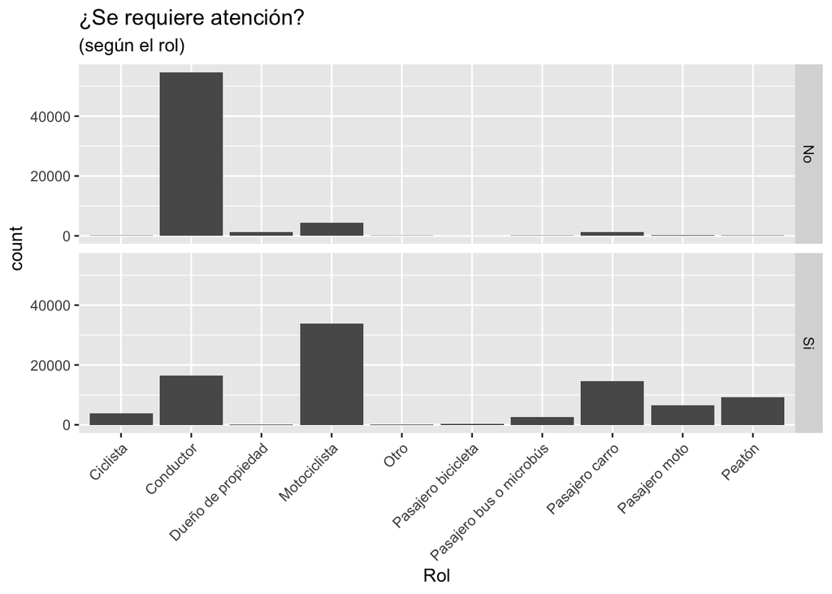

```r
ggplot(data4, aes(x = Rol)) +
  geom_histogram(stat = "count") +
  facet_grid(c("Requiere.atencion")) +
  theme(axis.text.x = element_text(angle = 45, hjust = 1)) +
  ggtitle("¿Se requiere atención?", subtitle = "(según el rol)")
```

Como se observa hay una gran distribución de los datos según el tipo de rol, donde la mayor cantidad de atención por parte de los servicios de tránsito tienen que ver con accidentados motociclistas, pasajeros de carro o conductores.

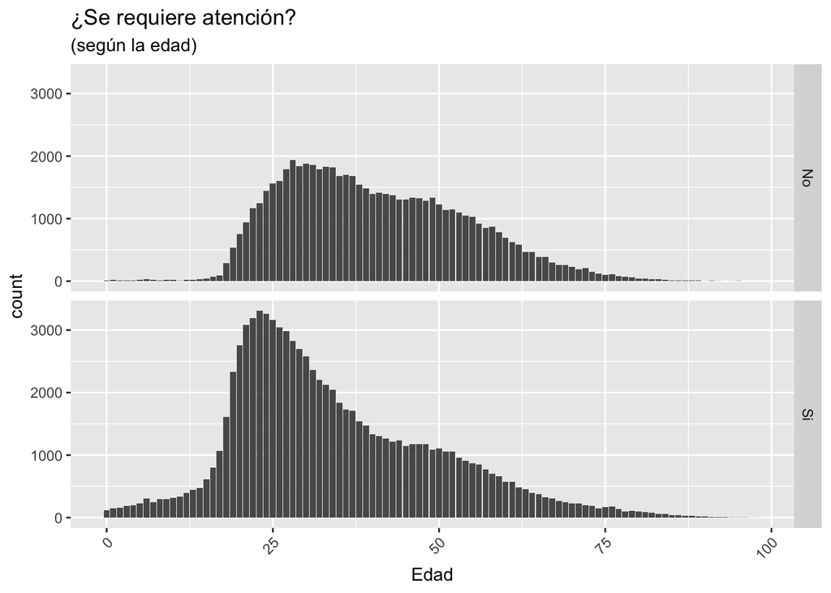

```r
ggplot(data4, aes(x = Edad)) +
  geom_histogram(stat = "count") +
  facet_grid(c("Requiere.atencion")) +
  theme(axis.text.x = element_text(angle = 45, hjust = 1)) +
  ggtitle("¿Se requiere atención?", subtitle = "(según la edad)")
```

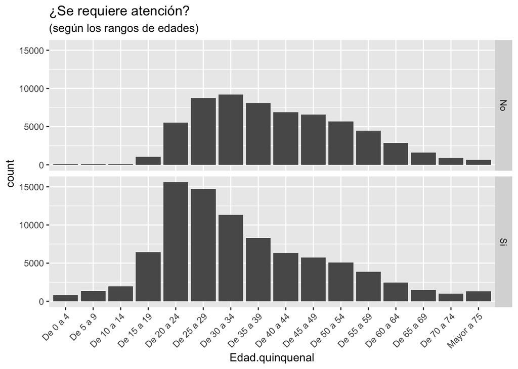

```r
ggplot(data4, aes(x = Edad.quinquenal)) +
  geom_histogram(stat = "count") +
  facet_grid(c("Requiere.atencion")) +
  theme(axis.text.x = element_text(angle = 45, hjust = 1)) +
  ggtitle("¿Se requiere atención?", subtitle = "(según los rangos de edades)")
```

Con respecto a las edades o los rangos de edad, la atención principal por parte de los servicios se observa entre el rango de 20 hasta 40 años. De estas 2 variables se va a tomar la de **Edad.quinquenal** para desarrollar el modelo de agrupamiento.

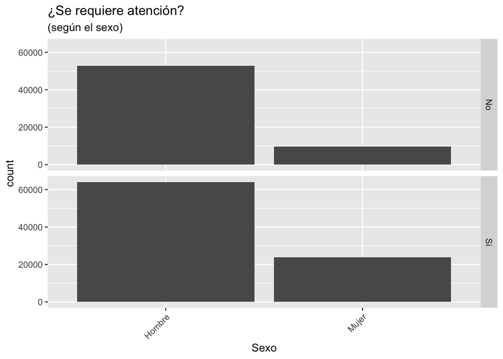

```r
ggplot(data4, aes(x = Sexo)) +
  geom_histogram(stat = "count") +
  facet_grid(c("Requiere.atencion")) +
  theme(axis.text.x = element_text(angle = 45, hjust = 1)) +
  ggtitle("¿Se requiere atención?", subtitle = "(según el sexo)")
```

Según la variable de sexo, se observa una mayor cantidad de mujeres que requieren atención con respecto a cuando no requiren atención.

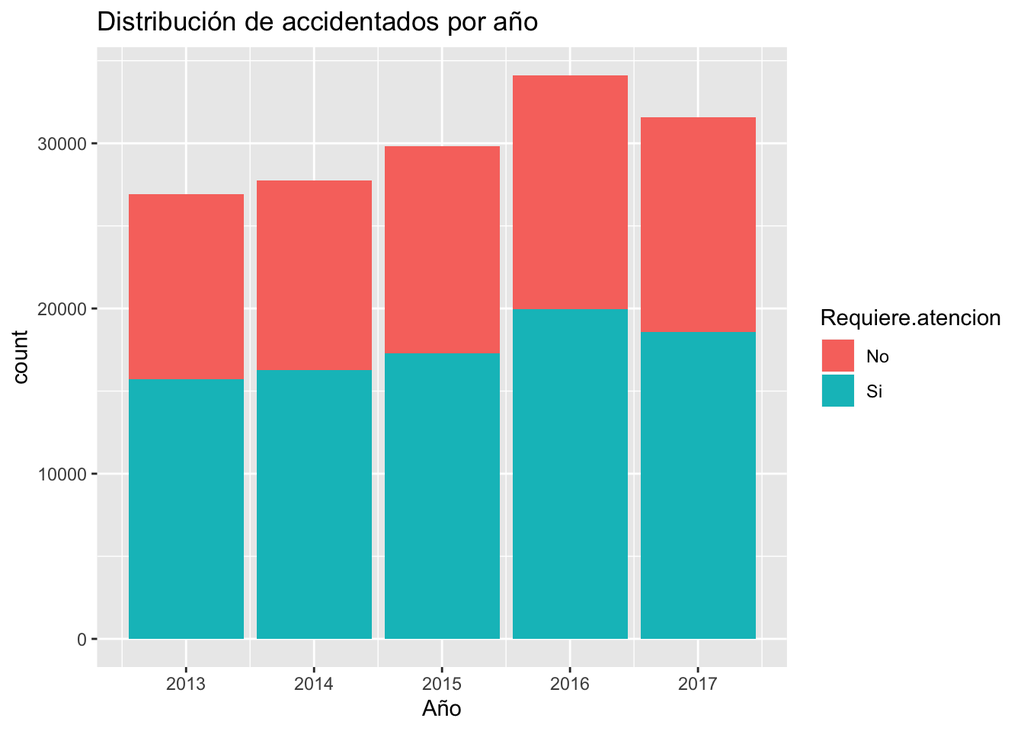

```r
ggplot(data4, aes(x = Año, fill = Requiere.atencion)) +
  geom_histogram(stat = "count") +
  ggtitle("Distribución de accidentados por año")
```

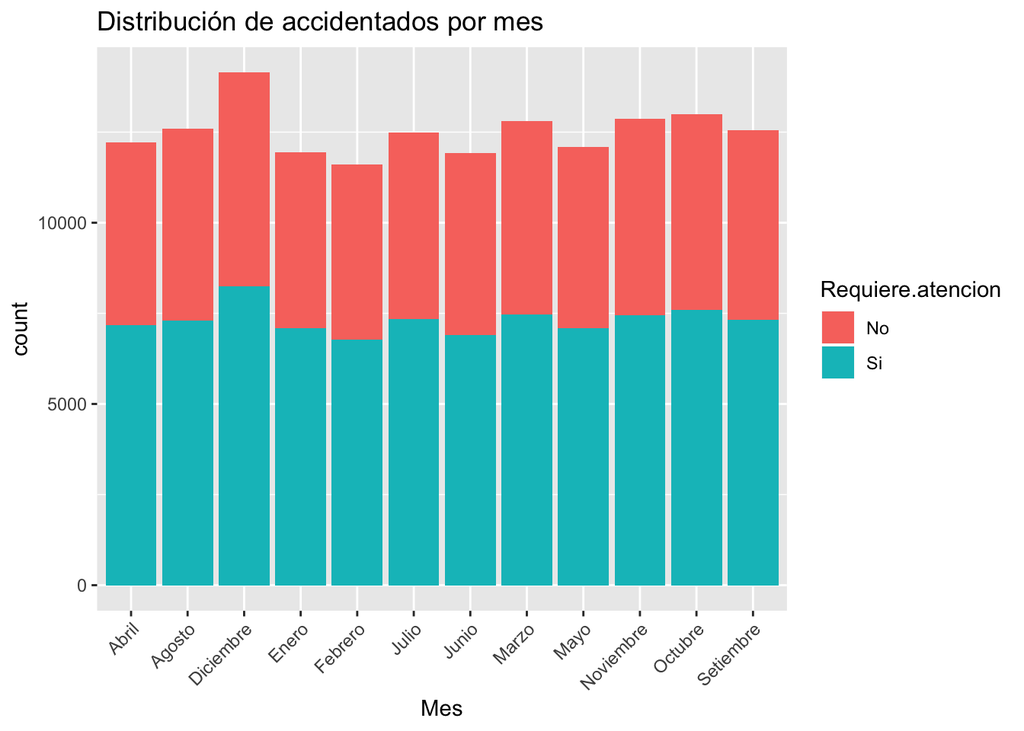

```r
ggplot(data4, aes(x = Mes, fill = Requiere.atencion)) +
  geom_histogram(stat = "count") +
  theme(axis.text.x = element_text(angle = 45, hjust = 1)) +
  ggtitle("Distribución de accidentados por mes")
```

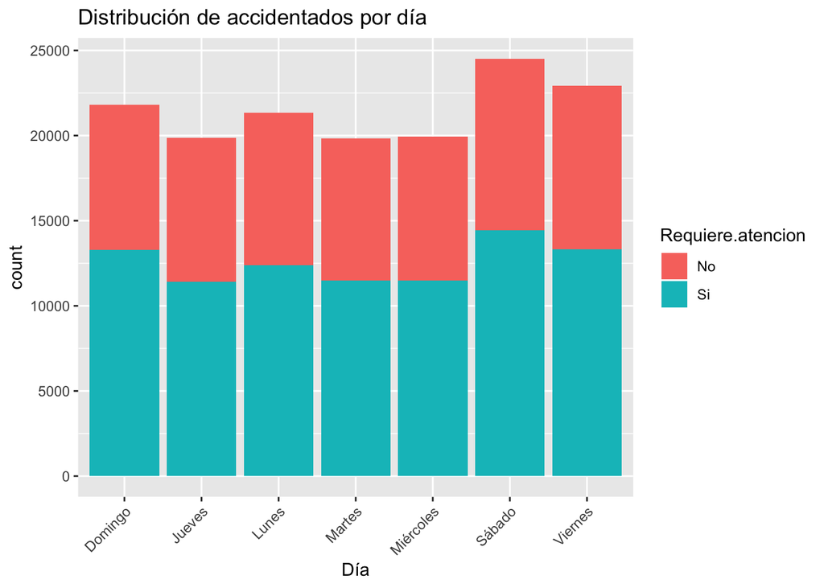

```r
ggplot(data4, aes(x = Día, fill = Requiere.atencion)) +
  geom_histogram(stat = "count") +
  theme(axis.text.x = element_text(angle = 45, hjust = 1)) +
  ggtitle("Distribución de accidentados por día")
```

Con respecto a las variables de año, mes y día se observa una mayor cantidad de accidentes que requieren atención los fines de semana (de viernes a domingo), además el mes con mayor cantidad de accidentes que requieren atención es Diciembre. Finalmente, de los años reportados en los datos, 2016 posee la mayor cifra de accidentes, seguido por el 2017.

De estas ultimas variables se pueden utilizar las de mes y día para el modelo. La variable de año fuera de ser un histórico no presenta valor a la hora de generar la clasificación, aunque denota una leve tendencia en el incremento total de accidentes en el país (esto en términos generales indica que se debe incrementar la capacidad de las fuerzas de tránsito para resolver accidentes).

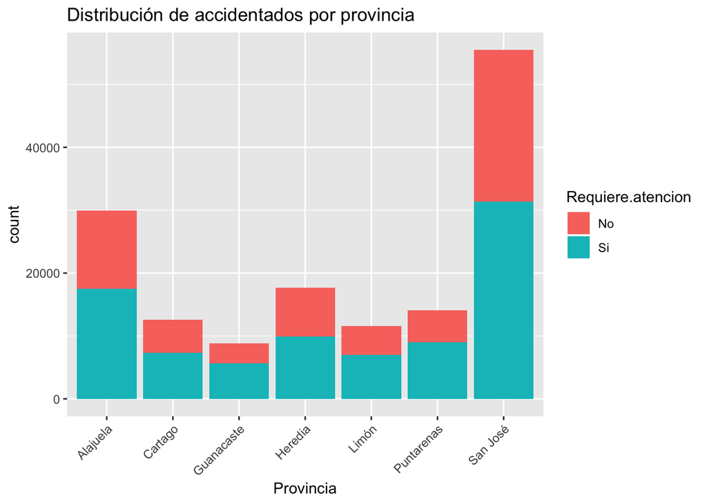

```r
ggplot(data4, aes(x = Provincia, fill = Requiere.atencion)) +
  geom_histogram(stat = "count") +
  theme(axis.text.x = element_text(angle = 45, hjust = 1)) +
  ggtitle("Distribución de accidentados por provincia")
```

Finalmente, con respecto a los accidentes según la provicia, se observa una mayor cantidad de accidentes en San José y Alajuela (tanto que requieran atención, como que no). Esto es representativo a la distrubución de la población en el país y no es útil para el objetivo del modelo (esto en términos generales indica cómo se debe distribuir la capacidad de las fuerzas de tránsito para resolver accidentes). Los datos de cantones y distritos se deben comportar de manera similar (por lo que no fueron graficados).

## Creación del Modelo

Se van a crear 5 modelos distintos para agrupar los perfiles de accidentados entre si requiren atención o no. Se van a utilizar los siguientes tipos de clasificación supervisada: árboles de decisión, random forest, regresión logística, k-vecinos más próximos (KNN) y máquinas de soporte vectorial (SVM).

Empecemos por dividir los datos aleatoriamente entre un conjunto para entrenamiento y otro para pruebas posteriores en la sección de evaluación del modelo.

**Adicionalmente, el conjunto de datos de pruebas se va a subdividir en 2: un dataset de validación y otro de pruebas.**

```r
set.seed(345)
data_split <- sample.split(data4$Requiere.atencion, SplitRatio = 0.6)
data_train <- subset(data4, data_split == TRUE)
data_validation_and_test <- subset(data4, data_split == FALSE)

# Acá se divide el dataset de pruebas en 2 datasets adicionales.
data_validation_and_test_split <- sample.split(data_validation_and_test$Requiere.atencion, SplitRatio = 0.5)
data_validation <- subset(data_validation_and_test, data_validation_and_test_split == TRUE)
data_test <- subset(data_validation_and_test, data_validation_and_test_split == FALSE)
```

Para los modelos se va a utilizar la siguiente fórmula basada en el entendimiento de los datos realizado previamente:

**Requiere.atencion = Rol + Edad.quinquenal + Sexo + Mes + Día**

Primero se crea el modelo de árbol de decisión para el dataset.

```r
arbol_decision_model <- rpart(Requiere.atencion ~ Rol + Edad.quinquenal + Sexo + Mes + Día,
                              data = data_train,
                              method = "class")

arbol_decision_predicciones <- predict(arbol_decision_model,
                                       newdata = data_test,
                                       type = "class")
```

A continuación se crea el modelo random forest para el dataset.

```r
random_forest_model <- randomForest(Requiere.atencion ~ Rol + Edad.quinquenal + Sexo + Mes + Día,
                                data = data_train[1:1000,])

random_forest_predicciones <- predict(random_forest_model,
                                      newdata = data_test,
                                      type = "class")
```

Luego se crea el modelo para regresión logística usando el dataset.

```r
regresion_logistica_model <- glm(Requiere.atencion ~ Rol + Edad.quinquenal + Sexo + Mes + Día,
                                data = data_train,
                                family = binomial)

regresion_logistica_predicciones <- predict(regresion_logistica_model,
                                            newdata = data_test,
                                            type = "response")
```

También se crea el modelo para KNN usando el dataset.

```r
knn_train_control <- trainControl()
knn_model <- train(Requiere.atencion ~ Rol + Edad.quinquenal + Sexo + Mes + Día,
                   data = data_train[1:1000,],
                   method = "knn",
                   trControl = knn_train_control)

knn_predicciones <- predict(knn_model,
                            newdata = data_test)
```

Finalmente se crea el modelo para SVM usando el dataset.

```r
svm_modelo <- svm(Requiere.atencion ~ Rol + Edad.quinquenal + Sexo + Mes + Día,
                  data = data_train[1:1000,],
                  kernel = 'linear',
                  cross = 2,
                  scale = FALSE)

svm_predicciones <- predict(svm_modelo,
                            newdata = data_test)
```

Como se observa en los chunks anteriores, se realizó de un solo las predicciones con el dataset de test. Por lo cual podemos realizar a continuación una validación inicial del desempeño de los modelos.

**Matriz de confusión y desempeño del modelo de árbol de decisión**

```r
table(data_test$Requiere.atencion, arbol_decision_predicciones)
```

```
##     arbol_decision_predicciones
##         No    Si
##   No 11201  1277
##   Si  3328 14231
```

```r
arbol_decision_predicciones_auc <- ROCR::prediction(c(arbol_decision_predicciones),
                                                    c(data_test$Requiere.atencion))
as.numeric(performance(arbol_decision_predicciones_auc, measure = "auc")@y.values)
```

```
## [1] 0.8540637
```

**Matriz de confusión y desempeño del modelo random forest**

```r
table(data_test$Requiere.atencion, random_forest_predicciones)
```

```
##     random_forest_predicciones
##         No    Si
##   No 10514  1964
##   Si  3087 14472
```

```r
random_forest_predicciones_auc <- ROCR::prediction(c(random_forest_predicciones),
                                                   c(data_test$Requiere.atencion))
as.numeric(performance(random_forest_predicciones_auc, measure = "auc")@y.values)
```

```
## [1] 0.8333979
```

**Matriz de confusión y desempeño del modelo de regresión logística**

```r
table(data_test$Requiere.atencion, regresion_logistica_predicciones >= 0.8)
```

```
##
##      FALSE  TRUE
##   No 11220  1258
##   Si  3362 14197
```

```r
regresion_logistica_predicciones_auc <- ROCR::prediction(c(regresion_logistica_predicciones),
                                                         c(data_test$Requiere.atencion))
as.numeric(performance(regresion_logistica_predicciones_auc, measure = "auc")@y.values)
```

```
## [1] 0.8816993
```

**Matriz de confusión y desempeño del modelo KNN**

```r
table(data_test$Requiere.atencion, knn_predicciones)
```

```
##     knn_predicciones
##         No    Si
##   No 10795  1683
##   Si  3595 13964
```

```r
knn_predicciones_auc <- ROCR::prediction(c(knn_predicciones),
                                         c(data_test$Requiere.atencion))
as.numeric(performance(knn_predicciones_auc, measure = "auc")@y.values)
```

```
## [1] 0.8301922
```

**Matriz de confusión y desempeño del modelo SVM**

```r
table(data_test$Requiere.atencion, svm_predicciones)
```

```
##     svm_predicciones
##         No    Si
##   No 11201  1277
##   Si  3328 14231
```

```r
svm_predicciones_auc <- ROCR::prediction(c(svm_predicciones),
                                         c(data_test$Requiere.atencion))
as.numeric(performance(svm_predicciones_auc, measure = "auc")@y.values)
```

```
## [1] 0.8540637
```

Estos resultados nos sirven como insumo para poder luego comparar con el resultado de la siguiente sección de optimización de los modelos.

## Optimización de Hiperparámetros del Modelo

Acá vamos a buscar la mejor configuración para cada uno de los modelos de forma que se puedan optimizar para mejorar la precisión de la agrupación de las predicciones.

**Optimización de hiperparámetros del modelo de árbol de decisión**

```r
arbol_decision_tune = tune.rpart(formula = Requiere.atencion ~ Rol + Edad.quinquenal + Sexo + Mes + Día,
                                 data = data_train)
arbol_decision_best_model = arbol_decision_tune$best.model
summary(arbol_decision_best_model)
```

```
## Call:
## best.rpart(formula = Requiere.atencion ~ Rol + Edad.quinquenal +
##     Sexo + Mes + Día, data = data_train)
##   n= 90110
##
##          CP nsplit rel error    xerror        xstd
## 1 0.6352514      0 1.0000000 1.0000000 0.003951726
## 2 0.0100000      1 0.3647486 0.3647486 0.002875299
##
## Variable importance
##             Rol Edad.quinquenal            Sexo
##              78              18               5
##
## Node number 1: 90110 observations,    complexity param=0.6352514
##   predicted class=Si  expected loss=0.4154256  P(node) =1
##     class counts: 37434 52676
##    probabilities: 0.415 0.585
##   left son=2 (43344 obs) right son=3 (46766 obs)
##   Primary splits:
##       Rol             splits as  RLLRRRRRRR, improve=21514.340000, (0 missing)
##       Edad.quinquenal splits as  RRRRRLLLLLLLLLLL, improve= 2237.660000, (0 missing)
##       Sexo            splits as  -LR, improve=  868.322600, (0 missing)
##       Día             splits as  RLLLLLL, improve=   20.286400, (0 missing)
##       Mes             splits as  RLLRRRLLRLRR, improve=    4.345759, (0 missing)
##   Surrogate splits:
##       Edad.quinquenal splits as  RRRRRRLLLLLLLLLL, agree=0.627, adj=0.225, (0 split)
##       Sexo            splits as  -LR, agree=0.547, adj=0.059, (0 split)
##
## Node number 2: 43344 observations
##   predicted class=No  expected loss=0.2256829  P(node) =0.4810121
##     class counts: 33562  9782
##    probabilities: 0.774 0.226
##
## Node number 3: 46766 observations
##   predicted class=Si  expected loss=0.08279519  P(node) =0.5189879
##     class counts:  3872 42894
##    probabilities: 0.083 0.917
```

```r
arbol_decision_predicciones <- predict(arbol_decision_best_model,
                                       newdata = data_test,
                                       type = "class")

table(data_test$Requiere.atencion, arbol_decision_predicciones)
```

```
##     arbol_decision_predicciones
##         No    Si
##   No 11201  1277
##   Si  3328 14231
```

```r
arbol_decision_predicciones_auc <- ROCR::prediction(c(arbol_decision_predicciones),
                                                    c(data_test$Requiere.atencion))
as.numeric(performance(arbol_decision_predicciones_auc, measure = "auc")@y.values)
```

```
## [1] 0.8540637
```

**Optimización de hiperparámetros del modelo random forest**

```r
random_forest_tune = tune.randomForest(Requiere.atencion ~ Rol + Edad.quinquenal + Sexo + Mes + Día,
                                 data = data_train[1:1000,])
random_forest_best_model = random_forest_tune$best.model
summary(random_forest_best_model)
```

```
##                 Length Class  Mode
## call               3   -none- call
## type               1   -none- character
## predicted       1000   factor numeric
## err.rate        1500   -none- numeric
## confusion          6   -none- numeric
## votes           2000   matrix numeric
## oob.times       1000   -none- numeric
## classes            2   -none- character
## importance         5   -none- numeric
## importanceSD       0   -none- NULL
## localImportance    0   -none- NULL
## proximity          0   -none- NULL
## ntree              1   -none- numeric
## mtry               1   -none- numeric
## forest            14   -none- list
## y               1000   factor numeric
## test               0   -none- NULL
## inbag              0   -none- NULL
## terms              3   terms  call
```

```r
random_forest_predicciones <- predict(random_forest_best_model,
                                      newdata = data_test,
                                      type = "class")

table(data_test$Requiere.atencion, random_forest_predicciones)
```

```
##     random_forest_predicciones
##         No    Si
##   No 10537  1941
##   Si  3081 14478
```

```r
random_forest_predicciones_auc <- ROCR::prediction(c(random_forest_predicciones),
                                                   c(data_test$Requiere.atencion))
as.numeric(performance(random_forest_predicciones_auc, measure = "auc")@y.values)
```

```
## [1] 0.8344903
```

**Optimización de hiperparámetros del modelo regresión logística**

No se realizó optimización de hiperparámetros a este modelo con el objetivo de comparar su resultado (actualmente el mejor) con respecto a la optimización del resto. Además el paquete (stats) no posee método de optimización de hiperparámetros para regresión logística.

**Optimización de hiperparámetros del modelo SVM**

```r
svm_tune = tune.svm(Requiere.atencion ~ Rol + Edad.quinquenal + Sexo + Mes + Día,
                                 data = data_train[1:1000,])
svm_best_model = svm_tune$best.model
summary(svm_best_model)
```

```
##
## Call:
## best.svm(x = Requiere.atencion ~ Rol + Edad.quinquenal + Sexo +
##     Mes + Día, data = data_train[1:1000, ])
##
##
## Parameters:
##    SVM-Type:  C-classification
##  SVM-Kernel:  radial
##        cost:  1
##
## Number of Support Vectors:  514
##
##  ( 262 252 )
##
##
## Number of Classes:  2
##
## Levels:
##  No Si
```

```r
svm_predicciones <- predict(svm_best_model,
                            newdata = data_test)

table(data_test$Requiere.atencion, svm_predicciones)
```

```
##     svm_predicciones
##         No    Si
##   No 10929  1549
##   Si  3318 14241
```

```r
svm_predicciones_auc <- ROCR::prediction(c(svm_predicciones),
                                         c(data_test$Requiere.atencion))
as.numeric(performance(svm_predicciones_auc, measure = "auc")@y.values)
```

```
## [1] 0.8434493
```

## Evaluación Final del Modelo

A continuación se evaluan los resultados obtenidos en los distintos modelos posteriormente de la optimización de hiperparámetros con el uso del dataset de validación y a través de una matriz de confusión para cada uno. A su vez mostramos las gráficas de la curva ROC.

**Matriz de confusión, desempeño del modelo, y gráfica de ROC de árbol de decisión**

```r
arbol_decision_predicciones <- predict(arbol_decision_best_model,
                                       newdata = data_validation,
                                       type = "class")

table(data_validation$Requiere.atencion, arbol_decision_predicciones)
```

```
##     arbol_decision_predicciones
##         No    Si
##   No 11197  1281
##   Si  3371 14187
```

```r
arbol_decision_predicciones_auc <- ROCR::prediction(c(arbol_decision_predicciones),
                                                    c(data_validation$Requiere.atencion))
as.numeric(performance(arbol_decision_predicciones_auc, measure = "auc")@y.values)
```

```
## [1] 0.8526735
```

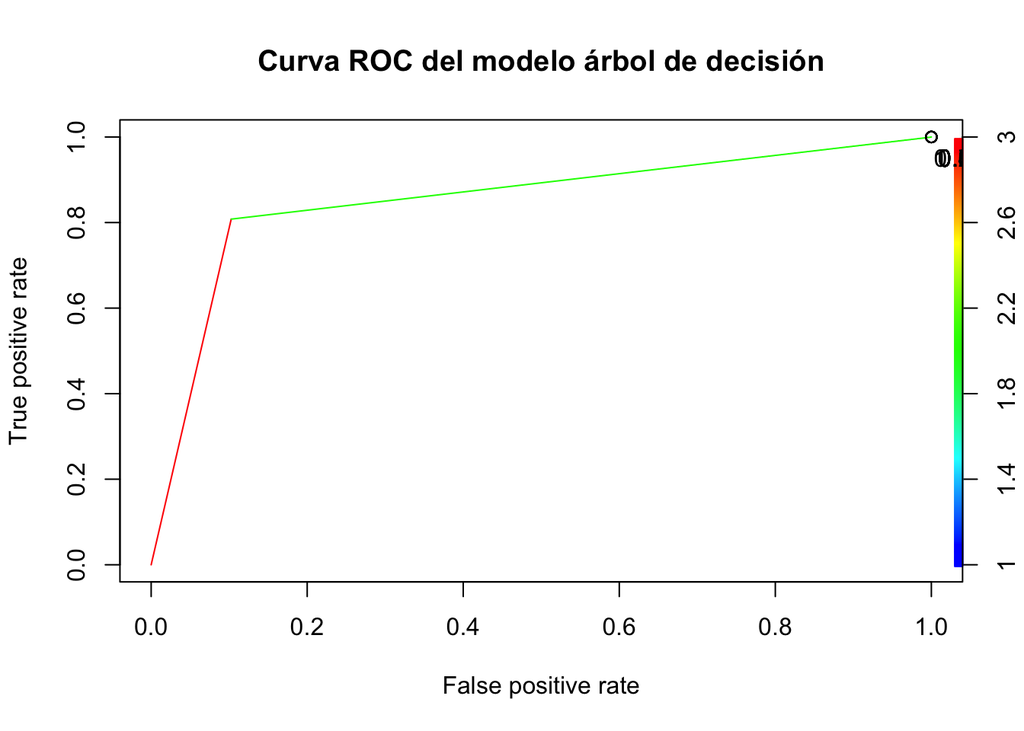

```r
plot(performance(arbol_decision_predicciones_auc, "tpr", "fpr"),
     colorize = T,
     print.cutoffs.at = seq(0, 1, by = 0.1),
     text.adj = c(-0.2, 1.7),
     main = 'Curva ROC del modelo árbol de decisión')
```

**Matriz de confusión , desempeño del modelo, y gráfica de ROC de random forest**

```r
random_forest_predicciones <- predict(random_forest_best_model,
                                      newdata = data_validation,
                                      type = "class")

table(data_validation$Requiere.atencion, random_forest_predicciones)
```

```
##     random_forest_predicciones
##         No    Si
##   No 10521  1957
##   Si  3174 14384
```

```r
random_forest_predicciones_auc <- ROCR::prediction(c(random_forest_predicciones),
                                                   c(data_validation$Requiere.atencion))
as.numeric(performance(random_forest_predicciones_auc, measure = "auc")@y.values)
```

```
## [1] 0.8311958
```

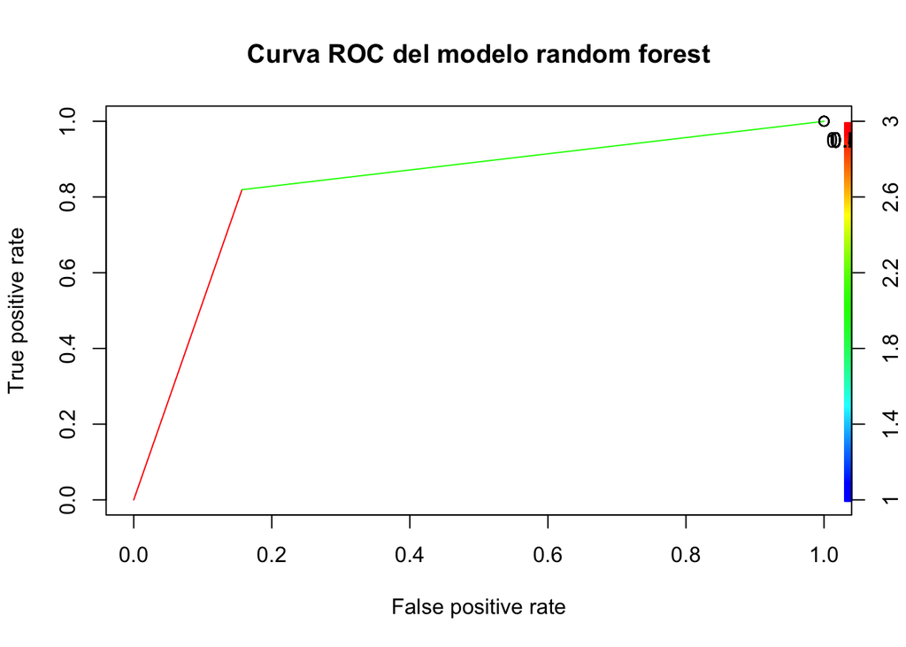

```r
plot(performance(random_forest_predicciones_auc, "tpr", "fpr"),
     colorize = T,
     print.cutoffs.at = seq(0, 1, by = 0.1),
     text.adj = c(-0.2, 1.7),
     main = 'Curva ROC del modelo random forest')
```

**Matriz de confusión, desempeño del modelo, y gráfica de ROC de regresión logística**

```r
regresion_logistica_predicciones <- predict(regresion_logistica_model,
                                            newdata = data_validation,
                                            type = "response")

table(data_validation$Requiere.atencion, regresion_logistica_predicciones >= 0.8)
```

```
##
##      FALSE  TRUE
##   No 11208  1270
##   Si  3396 14162
```

```r
regresion_logistica_predicciones_auc <- ROCR::prediction(c(regresion_logistica_predicciones),
                                                         c(data_validation$Requiere.atencion))
as.numeric(performance(regresion_logistica_predicciones_auc, measure = "auc")@y.values)
```

```
## [1] 0.8794513
```

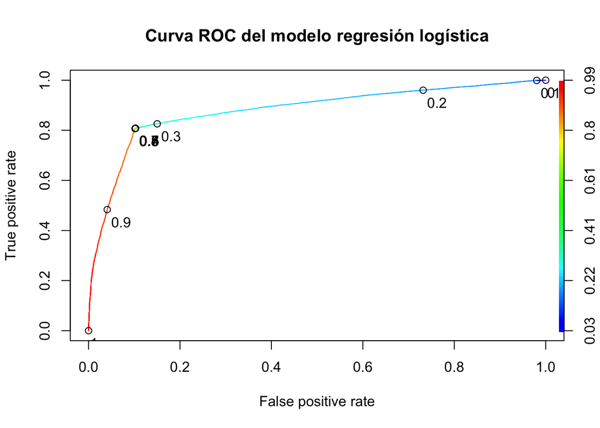

```r
plot(performance(regresion_logistica_predicciones_auc, "tpr", "fpr"),
     colorize = T,
     print.cutoffs.at = seq(0, 1, by = 0.1),
     text.adj = c(-0.2, 1.7),
     main = 'Curva ROC del modelo regresión logística')
```

**Matriz de confusión, desempeño del modelo, y gráfica de ROC de KNN**

```r
knn_predicciones <- predict(knn_model,
                            newdata = data_validation)

table(data_validation$Requiere.atencion, knn_predicciones)
```

```
##     knn_predicciones
##         No    Si
##   No 10762  1716
##   Si  3632 13926
```

```r
knn_predicciones_auc <- ROCR::prediction(c(knn_predicciones),
                                         c(data_validation$Requiere.atencion))
as.numeric(performance(knn_predicciones_auc, measure = "auc")@y.values)
```

```
## [1] 0.8278103
```

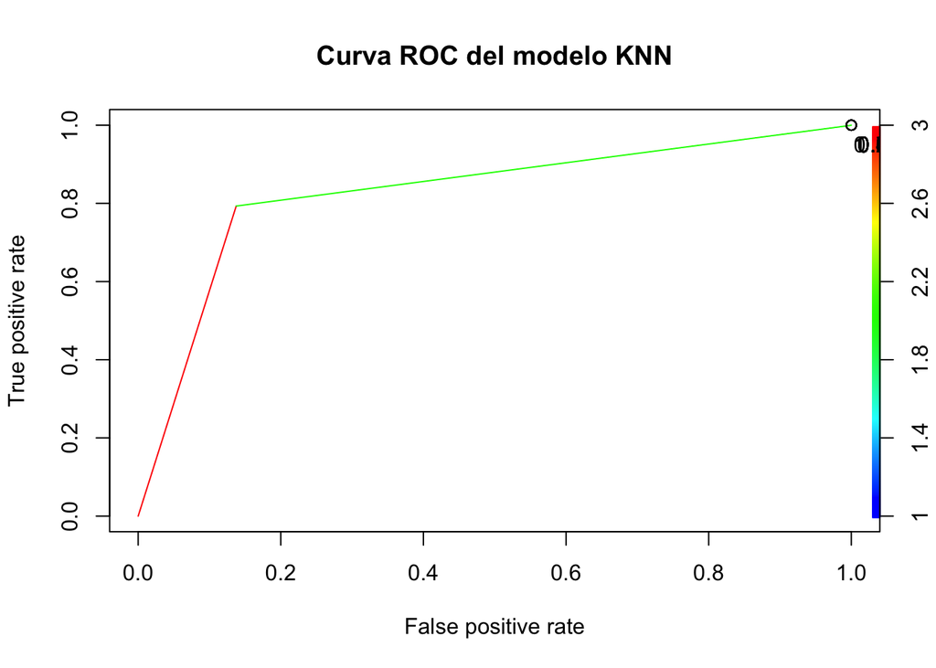

```r
plot(performance(knn_predicciones_auc, "tpr", "fpr"),
     colorize = T,
     print.cutoffs.at = seq(0, 1, by = 0.1),
     text.adj = c(-0.2, 1.7),
     main = 'Curva ROC del modelo KNN')
```

**Matriz de confusión, desempeño del modelo, y gráfica de ROC de SVM**

```r
svm_predicciones <- predict(svm_best_model,
                            newdata = data_validation)

table(data_validation$Requiere.atencion, svm_predicciones)
```

```
##     svm_predicciones
##         No    Si
##   No 10953  1525
##   Si  3356 14202
```

```r
svm_predicciones_auc <- ROCR::prediction(c(svm_predicciones),
                                         c(data_validation$Requiere.atencion))
as.numeric(performance(svm_predicciones_auc, measure = "auc")@y.values)
```

```
## [1] 0.8433235
```

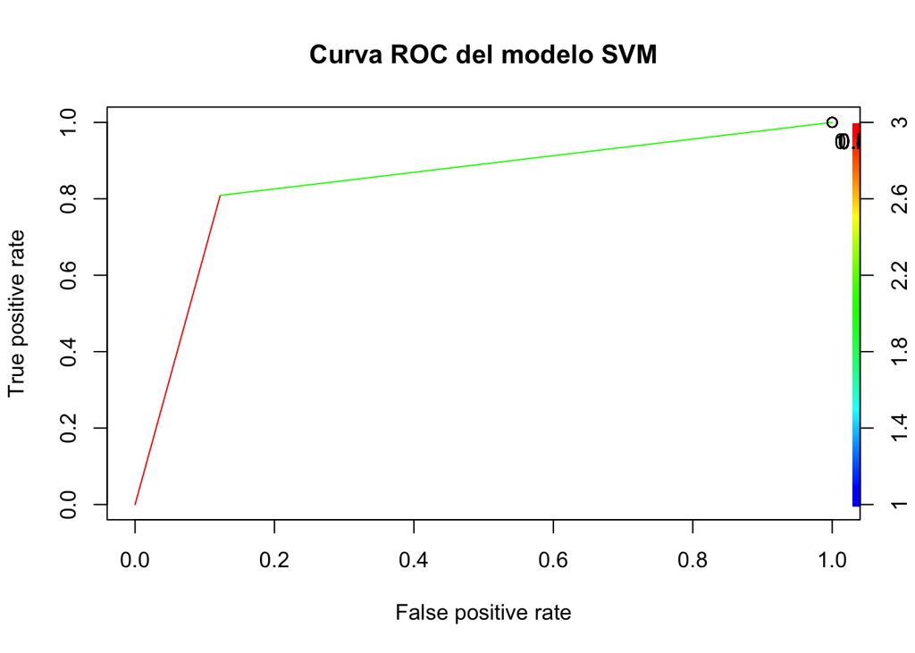

```r
plot(performance(svm_predicciones_auc, "tpr", "fpr"),
     colorize = T,
     print.cutoffs.at = seq(0, 1, by = 0.1),
     text.adj = c(-0.2, 1.7),
     main = 'Curva ROC del modelo SVM')
```

## Conclusiones

- Se observa el mejor resultado de clasificación se sigue dando al emplear el modelo de regresión logística sobre la formula empleada para determinar si las fuerzas policiales de tránsito requieren o no atender un caso con heridos o muertes.
- Del mismo modo, se observa un buen rendimiento sobre los modelos de árbol de decisión, random forest y SVM. Que además son fáciles de implementar y no requieren de mucho preprocesamiento de los datos.
- El modelo de KNN es el que da menor rendimiento y a su vez, debido a la estructura de los datos, es el que más tiempo de procesamiento toman para retornar un modelo de clasificación.
- El dataset inicial de personas accidentadas cuenta con un set de datos limitados que podría verse mejorado al emplear a su vez una combinación con los datos de accidentes vehiculares del COSEVI. Pero debido a la estructura de ambos datasets es difícil buscar una forma de combinarlos para brindar más detalles.
- No se empleó ANN dentro de los modelos debido al alto tiempo de procesamiento que tomaría retornar una solución debido a la gran cantidad de variables categóricas que requieren transformarse en matrices de valores dummies.
- No es recomendado el uso de KNN con la cantidad de variables que se generan posteriormente de transformar las variables categóricas a matrices de valores dummies (alrededor de 45 variables distintas).